# Introduction to R

## Learning Objectives

1. Be able to download and open R and RStudio.
2. Understand how to import data to R.
3. Understand how to create a graph in R.

[Link to Lecture](https://docs.google.com/presentation/d/1VJUOzvqMubmcRoJWAklv6ZlwM5WydgO7vyAwgsnPYsk/edit?usp=sharing)

Links to Tutorials

[Importing data into R](https://rpubs.com/jwesner/530743) [Transforming data from wide to long format (Tidying)](https://rpubs.com/jwesner/530744) [Visualization](https://rpubs.com/jwesner/530745) [Model - linear regression](https://rpubs.com/jwesner/530746) [Model with merged data (merging two data sets and running a linear regression)](https://rpubs.com/jwesner/531334)

## R and RStudio

1. Download R: (https://mirror.las.iastate.edu/CRAN/). Follow the link above and choose your operating system - Linux, Mac OS, or Windows
2. Download RStudio: (https://rstudio.com/products/rstudio/download/#download)

R is a free statistical and graphing program [@R_core_team2020]. All of the examples in this book are generated using R. Actually, that’s not quite correct. While R is the workhorse, the examples in this book are generated through an interface to R called RStudio [@rstudio_2020].

R looks like this:

[figure not shown]

*Download only*

RStudio looks like this:

[figure not shown]

*Download, open, and use*

Once you’ve downloaded both programs, you’ll only need to open RStudio. It automatically uses R in the background. It is possible to do everything only in base R, but we prefer RStudio as a more user-friendly interface.[^1]

## How to Use This Chapter

This book is not meant as a stand-alone R reference. It is meant as a companion to university-level labs and lectures, in which students can work through examples with an instructor or TA nearby to fill in the gaps and troubleshoot.

When starting R, these are the types of questions many students have:

*“Is this the right program?”* *“What is a script again?”* *“How do you make the arrow?”* *“What is that squiggly sign?”* *“I ran the code and nothing happened…”*

In other words, we expect students to have lots of questions in this new and unfamiliar environment. Everyone started this way and the easiest way to find the answers is to ask an expert.

However, there are lots of excellent R guides out there for students who are interested in learning more detail. Here are a few of our favorites:

**R for Data Science** (free) - https://r4ds.had.co.nz/ [@wickham2016r] **The R Book** [@crawley2012r] **Getting Started with R: An Introduction for Biologists** [@beckerman2017getting] **Data Visualization: A Practical Introduction** [@healy2018data] **dplyr and tidyr cheatsheets** - (https://rstudio.com/wp-content/uploads/2015/02/data-wrangling-cheatsheet.pdf) **ggplot2 cheatsheet** - (https://rstudio.com/wp-content/uploads/2015/03/ggplot2-cheatsheet.pdf)

## Data Analysis Workflow

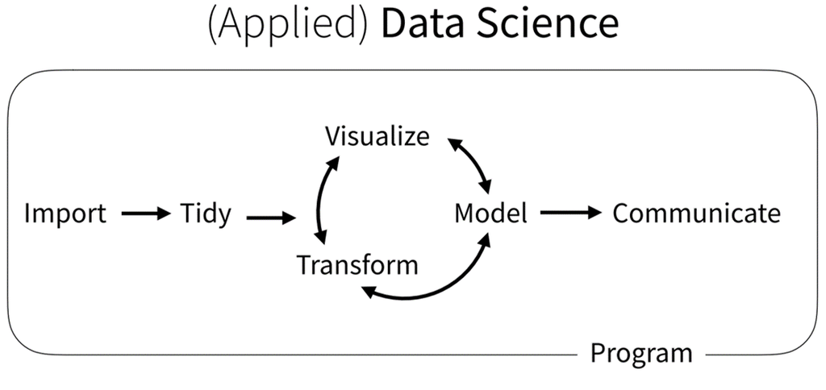

In this book, we focus on learning a few fundamental tasks that are common to the workflow of most data science projects [@wickham_welcome_2019]. Nearly every study that includes data has a workflow similar to that above. We gather data, get it into a program (Import), get it in the right format (Tidy), and then analyze it with plots (Visualizations), Models, Transformations, etc. When we’ve finished, we communicate the results to our peers. You’ll learn how to complete these steps in R because its designed specifically for each of these steps. But the workflow applies regardless of the software you use.

## Getting Started in RStudio

Before the fun stuff happens, we need to determine where things will be saved on our computer. If you’d prefer to skip this step, that is OK. Just be prepared for certain doom.

### Create a folder on your computer for your analyses

For example, if this is for a class called Biology 280, you might create a folder called BIO280_R. If you have data to analyze (like an Excel file or a .csv), save it in this folder as well.

### Open RStudio

Click the RStudio icon

[figure not shown]

### Create a project

*File -> New Project… -> Existing Directory -> Browse ->* [NAME OF YOUR FOLDER]

You only need to do this once. After you create a project, all of the work you do within that project (data analysis, graphs, text) will be saved in it. If it all goes well, you should see a screen like this, with the name of your project in the upper right hand corner.

[figure not shown]

### Open a script

*File -> New File -> R Script* or *ctrl+shift+N*

You should now see a screen like the one below, with four windows.

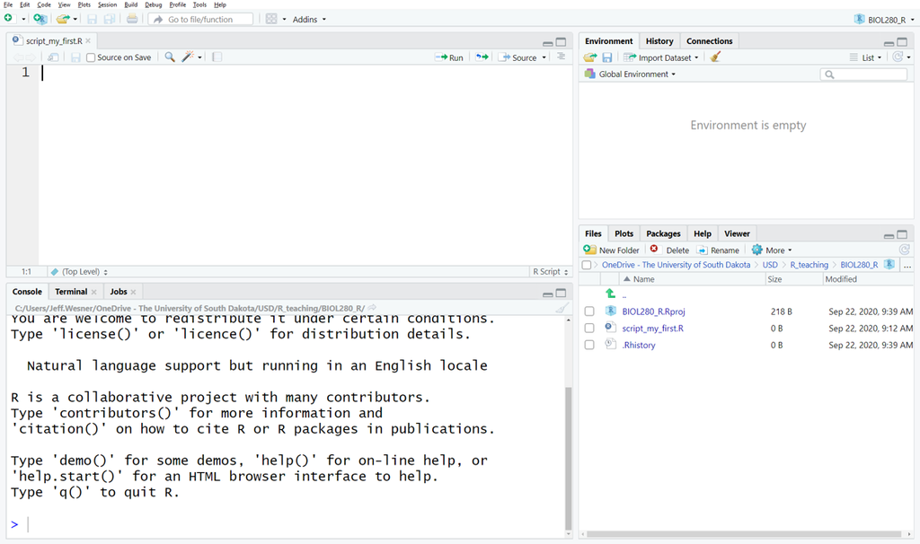

The window on the lower right shows all of the files in the folder. If you add something to that folder from outside of R, it will show up here as well.

The window on the upper right shows your Environment. When you create something in R, like a new data frame or a plot, it will show up in the Environment (But it won’t be saved. More on that later).

The window on the upper left shows your script. This is where you tell R what to do.

The window on the bottom left is the Console. It keeps a running list of all of the procedures you perform. For example, if you run code in the script, it will show up here. When something goes wrong, you’ll also see the error message here.

### Install a package

Click anywhere on the script window so that you see the flashing prompt. Type the code below and then type *ctrl+enter*. (NOTE: If you just hit enter without adding ctrl, it won’t work. It will just move you to the next line. Get in the habit of typing *ctrl+enter* to run your code).

```r
#type this and then hit ctrl+enter
install.packages("tidyverse") # ctrl+enter
```

Like this:

[figure not shown]

The code above tells R to install a package called *tidyverse*. You only have to do this once. After it’s installed, it will always be available when you open R, but you’ll have to tell R when you want to use it each time by typing *library(tidyverse)* (see code below).

Packages are bits of code that someone wrote and then converted into a series of shortcuts. R has 1000’s of packages for just about any task you can think of. The *tidyverse* actually contains a bunch of other packages within it. As a result, when you install it for the first time, it will generate a lot of activity in your console, with red text and “https://..” links all over the place. That is all normal. Just give it a few minutes. You’ll know it’s done when you see the chevron > in the console.

### Your first script

Now you are ready for the fun parts. To begin coding your first script, we are going to take an unorthodox approach. Instead of starting with first principles, we’ll start with the Vizualize and Model steps from the workflow and then deconstruct that to learn the principles.

Copy the code below and paste it in your script. Then run the code (by clicking *ctrl+enter* from the first line down). Do not try to interpret it yet. There is a lot going on here. We’ll break it down next.

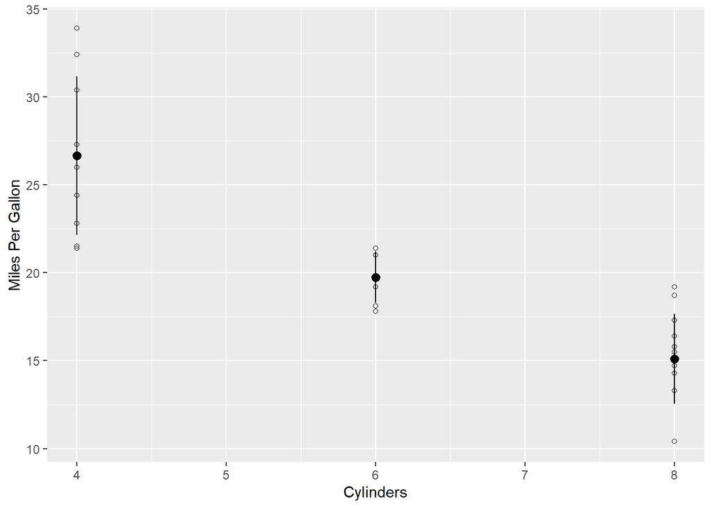

```r
#Copy this code, paste it in your script, and run it.
#load a package
library(tidyverse)

# make the data and "model" the mean and sd.
d <- mtcars %>%
  group_by(cyl) %>%
  mutate(mean = mean(mpg), sd = sd(mpg))

#plot the data
ggplot(data = d, aes(x = cyl,y = mpg)) +
  geom_point(shape = 21) +
  geom_pointrange(aes(y = mean, ymin = mean-sd, ymax = mean+sd)) +
  labs(y = "Miles Per Gallon",
       x = "Cylinders")
```

Here is what you just did:

1. Loaded the *tidyverse* package.
2. Created a data frame *d* that was a modified version of the data frame *mtcars*.
3. Added two new columns to *d*: one containing the mean mpg for each type of cylinder and another containing the standard deviation.
4. Plotted miles per gallon as a function of cylinders as raw data.
5. Added a mean and standard deviation to the plot.
6. Modified the axis names.

If you’re a normal person, this should all be mysterious. Here’s the good news. The code above is about as complex as we will get in this book. It is also modular. That is crucial. It means that you don’t have to know every step to get started. Each batch of code that preceeds *%>%* or *+* will run by itself.

Let’s break the code down into individual components:

**1) Loaded the *tidyverse* package.**

```r
#Copy this code, paste it in your script, and run it.
#load a package
library(tidyverse)
```

**What it does** This code uses the function *library()* to load a package called *tidyverse*. The rest of the code depends on loading this package first.

**Did it work?** Check the output in the console (lower left window). Red text is normal. It does not mean there is an error. If you see the prompt >, that is a good sign. If you see words like “there is no package called…”, “Error…”, “failed…”, then it probably didn’t work.

**Things to check if it doesn’t work**

- Did you install the package first?
- Did you misspell anything?
- Did you add a capital letter somewhere?
- Did you hit *enter* instead of *ctrl-enter*?

**2) Created a data frame *d* that was a modified version of the data frame *mtcars*.**

```r
#Copy this code, paste it in your script, and run it.
#load a package
library(tidyverse)

d <- mtcars
```

**What it does** This code creates a data frame called *d* that contains all of the data that are in *mtcars*. *mtcars* is one of many datasets that are built in to R. It contains data on things like miles per gallon, weight, and horsepower for different types of cars.

The symbol <- is how we assign bits of code to objects in R. It’s a combination of the lesser than sign < and the minus sign -. You will use this symbol all the time.

**Did it work?** Do you see an object named *d* in the Environment window (upper right) that has “32 obs. of 11 variables”? If not, it didn’t work.

Visually, the *d* in the Environment window is the only thing that will automatically show up if it worked. Another way to check is simply to view the data frame, like this:

```r
head(d)
```

```
##                    mpg cyl disp  hp drat    wt  qsec vs am gear carb
## Mazda RX4         21.0   6  160 110 3.90 2.620 16.46  0  1    4    4
## Mazda RX4 Wag     21.0   6  160 110 3.90 2.875 17.02  0  1    4    4
## Datsun 710        22.8   4  108  93 3.85 2.320 18.61  1  1    4    1
## Hornet 4 Drive    21.4   6  258 110 3.08 3.215 19.44  1  0    3    1
## Hornet Sportabout 18.7   8  360 175 3.15 3.440 17.02  0  0    3    2
## Valiant           18.1   6  225 105 2.76 3.460 20.22  1  0    3    1
```

This shows a snapshot of the first few rows of the data frame that exists in the object *d*. It is essentially the same as any other spreadsheet you might make in another program, like Excel. Each row contains information on mpg, cylinders (cyl), horsepower(hp), etc. for each type of car.

You can isolate individual columns like this:

```r
d %>% select(mpg, cyl) %>% head()
```

```
##                    mpg cyl
## Mazda RX4         21.0   6
## Mazda RX4 Wag     21.0   6
## Datsun 710        22.8   4
## Hornet 4 Drive    21.4   6
## Hornet Sportabout 18.7   8
## Valiant           18.1   6
```

Or check the types of columns like this:

```r
str(d)
```

```
## 'data.frame':    32 obs. of  11 variables:
##  $ mpg : num  21 21 22.8 21.4 18.7 18.1 14.3 24.4 22.8 19.2 ...
##  $ cyl : num  6 6 4 6 8 6 8 4 4 6 ...
##  $ disp: num  160 160 108 258 360 ...
##  $ hp  : num  110 110 93 110 175 105 245 62 95 123 ...
##  $ drat: num  3.9 3.9 3.85 3.08 3.15 2.76 3.21 3.69 3.92 3.92 ...
##  $ wt  : num  2.62 2.88 2.32 3.21 3.44 ...
##  $ qsec: num  16.5 17 18.6 19.4 17 ...
##  $ vs  : num  0 0 1 1 0 1 0 1 1 1 ...
##  $ am  : num  1 1 1 0 0 0 0 0 0 0 ...
##  $ gear: num  4 4 4 3 3 3 3 4 4 4 ...
##  $ carb: num  4 4 1 1 2 1 4 2 2 4 ...
```

This shows that the object *d* is a data frame with 32 observations (rows) of 11 variables (columns). It also lists the variables and gives a preview of the first 10 rows.

**Things to check if it doesn’t work**

- Did you misspell anything?
- Did you add a capital letter somewhere?
- Did you hit *enter* instead of *ctrl-enter*?
- Is there a space in the arrow < -? There shouldn’t be.

**Challenges**

- Give the data frame a different name other than *d*.
- Select other columns using the *select()* function.

**3) Added two new columns to *d*: one containing the mean mpg for each type of cylinder and another containing the standard deviation.**

```r
#Copy this code, paste it in your script, and run it.
#load a package
library(tidyverse)

# make the data and "model" the mean and sd
d <- mtcars %>%
  group_by(cyl) %>%
  mutate(mean = mean(mpg), sd = sd(mpg))
```

**What it does** This code adds a column summarizing the mean and sd of mpg for cars with different numbers of cylinders. We also have a new symbol %>% called a “pipe”. You can either type it directly or use a shortcut *ctrl-shift-m*. Think of it as a way of telling R “and then…”.

In sentence form, the code is saying this.

d <- mtcars %>%

*create a data frame called d that contains all of the data that are in mtcars and then…*